# diemr: Diagnostic index expectation maximisation in R

Natália Martínková, Stuart J.E. Baird

2026-01-13

# Quick start

The package `diemr` incorporates the diagnostic index expectation maximisation algorithm used to estimate which genomic alleles belong to which side of a barrier to gene flow. To start using `diemr`, load the package or install it from CRAN if it is not yet available:

```r
# Attempt to load a package, if the package was not available, install and load
if(!require("diemr", character.only = TRUE)){
    install.packages("diemr", dependencies = TRUE)
    library("diemr", character.only = TRUE)
}
```

Next, assemble paths to all files containing the data to be used by `diemr`. Here, we will use a tiny example dataset that is included in the package for illustrating the analysis workflow. A good practice is to check that all files contain data in the correct format for all individuals and markers. Additionally, the analysis will need a list with **ploidies for all genomic compartments and individuals**, and a vector with **indices of samples** that will be included in the analysis.

```r
filepaths <- system.file("extdata", "data7x3.txt", package = "diemr")
# Analysing six individuals
samples <- 1:6
# Assuming diploid markers of all individuals
ploidies = rep(list(rep(2, nchar(readLines(filepaths[1])[1]) - 1)), length(filepaths))
CheckDiemFormat(files = filepaths,
                ChosenInds = samples,
                ploidy = ploidies)
# File check passed: TRUE
# Ploidy check passed: TRUE
```

If the `CheckDiemFormat()` function fails, work through the error messages and fix the stored input files accordingly. The algorithm repeatedly accesses data from the harddisk, so seeing the passed file and variable check prior to the analysis is critical.

Starting from `diemr 1.4`, ploidy might now be assumed to be diploid for all individuals and all sites across all compartments by default. Use this only when compartments for the sex chromosomes are not identified.

To estimate the marker polarities, their diagnostic indices and support, run the function `diem()` with default settings. Here, we have only one file with data, so paralelisation is unnecessary, and we set `nCores = 1`. **The Windows operating system only allows for nCores = 1**. Other operating systems can process multiple genomic compartments (e.g. chromosomes) in parallel, the analysis of different genomic compartment files running on multiple processors.

```r
res <- diem(files = filepaths,
            ploidy = ploidies,
            markerPolarity = list(c(FALSE, FALSE, TRUE)),
            ChosenInds = samples,
            nCores = 1)
```

The result is a list, where the element `res$DI` contains a table with marker polarities, their diagnostic indices and support.

```r
res$DI
#   newPolarity         DI   Support Marker
# 1       FALSE  -4.872256 15.930181      1
# 2        TRUE  -3.520647 18.633399      2
# 3        TRUE -13.274822  6.130625      3
```

The column `newPolarity` means that marker 1 should be imported for subsequent analyses as is, and markers 2 and 3 should be imported with 0 replaced with 2 and 2 replaced with 0 (hereafter ‘flipped’ 0↔︎2). The marker 3 has the lowest diagnostic index and low support, indicating that the genotypes scored at this marker are poorly related to the barrier to gene flow arbitrated by the data.

With the marker polarities optimised to detect a barrier to gene flow, a plot of the polarised genome will show how genomic regions cross the barrier. First, the genotypes need to be imported with optimal marker polarities. Second, individual hybrid indices need to be calculated from the polarised genotypes. And last, the data will be plotted as a raster image.

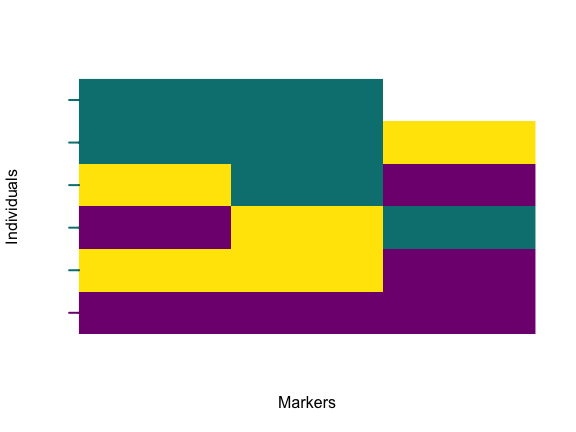

```r
genotypes <- importPolarized(file = filepaths,
                             changePolarity = res$markerPolarity,
                             ChosenInds = samples)

h <- apply(X = res$I4,
           MARGIN = 1,
           FUN = pHetErrOnStateCount)[1, ]

plotPolarized(genotypes = genotypes,
              HI = h[samples])
```

> CAUTION: This is just a **quick start** to get you started! For real datasets you will use the diagnostic index (DI) to filter the full set of sites you have analysed with `diem` in order to plot only those markers relevant to any barrier detected in the analysis.

# Input data

The `diemr` package uses a consise genome representation. Let’s have a small dataset of three markers genotyped for seven individuals.

```r
S0011222
S1210001
S02221U0
```

The genotypes encoded as `0` represent homozygotes for an allele attributed to barrier side A, `1` are heterozygous genotypes, `2` are homozygotes for another allele, attributed to barrier side B, and `U` (symbol “_” is also allowed) represents an unknown state or a third (fourth) allele. The power of `diem` lies in the assurance that the user does not need to determine the true assignment to  
barrier sides A and B before the analysis and the specific genotypes encoded as `0` and `2` respectively can be arbitrary.

The leading `S` on each line of the input file ensures that the marker genotypes are read in as a string on all operating systems. The `S` is dropped during import of the genotypes, and the dataset is imported as a character matrix of all sites.

# Multiple compartments with different ploidies

Some genomic compartments differ between individuals in their ploidy. For example, markers located on chromosome X in mammals will be diploid in females, but haploid in males. Ploidy differences between individuals influence calculation of the hybrid index, which in turn has an effect on the *diem* analysis.

To set up the *diem* analysis with multiple compartments, the markers with different individual ploidies must be stored in separate files. The file analysed in the **Quick start** chapter could contain markers from autosomes and an additional file will contain markers from an X chromosome, with individuals 2 and 6 being males. The respective ploidies for the second genomic compartment will be `c(2, 1, 2, 2, 2, 1, 2)`.

Arguments `files` and `ploidy` will need to reflect the information, taking care that the order of filenames corresponds to the order of elements in the list of ploidies. `diem` cannot check that the order of the elements is correct, only that the information is in the correct format.

```r
filepaths2 <- c(system.file("extdata", "data7x3.txt", package = "diemr"),
                system.file("extdata", "data7x10.txt", package = "diemr"))

ploidies2 <- list(rep(2, 7),
                  c(2, 1, 2, 2, 2, 1, 2))

CheckDiemFormat(files = filepaths2,
                ChosenInds = samples,
                ploidy = ploidies2)
# File check passed: TRUE
# Ploidy check passed: TRUE

# Set random seed for repeatibility of null polarities (optional)
set.seed(39583782)

# Run diem with verbose = TRUE to store hybrid indices with ploidy-aware allele counts
res2 <- diem(files = filepaths2,
             ploidy = ploidies2,
             markerPolarity = FALSE,
             ChosenInds = samples,
             nCores = 1,
             verbose = TRUE)
```

Plotting polarised genomes from multiple compartments requires separate import of the compartment data. The polarities in the `res2$markerPolarity` element are combined across all compartments.

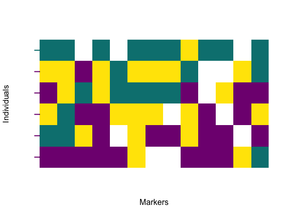

```r
# Import polarized genotypes for all compartments
genotypes2 <- importPolarized(files = filepaths2,
                       changePolarity = res2$markerPolarity,
                       ChosenInds = samples)

# Load individual hybrid indices from a stored file
h2 <- unlist(read.table("diagnostics/HIwithOptimalPolarities.txt"))

# Plot the polarised genotypes
plotPolarized(genotypes = genotypes2,
              HI = h2[samples])
```

Plotting all sites gives a good first impression on the diversity in the data. However, to examine the barrier to gene flow, markers with high diagnostic index will be more informative. Use the `ChosenSites` argument to specify which markers to display.

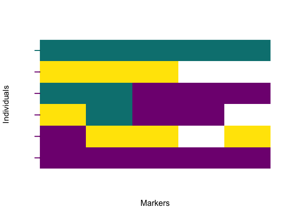

```r
# Select a threshold for the top diagnostic markers.
threshold <- quantile(res2$DI$DI, prob = 0.6)
# Create a vector identifying the diagnostic markers at the given threshold
markers <- res2$DI$DI > threshold
# Import only the selected markers
genotypes3 <- importPolarized(files = filepaths2,
                       changePolarity = res2$markerPolarity,
                       ChosenInds = samples,
                       ChosenSites = markers)
# Calculate hybrid index from diagnostic markers
h3 <- apply(genotypes3, 1, FUN = function(x) pHetErrOnStateCount(sStateCount(x)))[1, ]
# Plot diagnostic markers
plotPolarized(genotypes3, h3)
```

# Frequently asked questions

1. **How can I install `diemr` from the source?**

```r
install.packages(package = "diemr_1.4.2.tar.gz",
                 repos = NULL, type = "source")
```

Make sure to set the `R` working directory to the folder, where the package tarball is stored, or include a full path to the file within the quotes. Update the version number to the specific file.

2. **How can I calculate the hybrid indices from my polarised data?**

```r
apply(res$I4, MARGIN = 1, FUN = pHetErrOnStateCount)
#          [,1] [,2]      [,3]      [,4]      [,5]      [,6]
# p   0.5000000    0 0.3333333 0.5000000 0.8333333 1.0000000
# Het 0.3333333    0 0.6666667 0.3333333 0.3333333 0.0000000
# Err 0.0000000    0 0.0000000 0.0000000 0.0000000 0.3333333
```

To calculate the hybrid indices while ignoring uninformative sites (which will force all hybrid indices towards 0.5), filter the `importPolarised` data by the DI of each site.

3. **I expect more than two groups of samples in my data. Can I use `diemr`?**

Yes. Multiple barriers to gene flow between multiple groups of samples can be identified iteratively with help from the argument `ChosenInds`. For example, let’s assume that the individual 2 was identified as belonging to one side of the barrier and being separated from other by the steepest change in the hybrid index. In the next `diem` run, we exclude the individual 2.

```r
samples2 <- c(1, 3:6)
CheckDiemFormat(files = filepaths,
                ChosenInds = samples2,
                ploidy = ploidies)
# File check passed: TRUE
# Ploidy check passed: TRUE

res2 <- diem(files = filepaths,
             ChosenInds = samples2,
             ploidy = ploidies,
             nCores = 1,
             markerPolarity = list(c(FALSE, FALSE, TRUE)))

# calculate hybrid indices from updated I4
h.res2 <- apply(res2$I4,
                MARGIN = 1,
                FUN = pHetErrOnStateCount)[1, ]

# set names for the hybrid index values
h.res2 <- setNames(h.res2, nm = samples2)
#    1    3    4    5    6
# 0.50 0.33 0.50 0.83 1.00

# calculate the center of the maximum hybrid index change
diffs <- data.frame(rollmean = zoo::rollmean(sort(h.res2), k = 2),
                    diff = diff(sort(h.res2), lag = 1))
h.res2.c <- diffs$rollmean[which.max(diffs$diff)]
# [1] 0.6666667
```

Since the center of the barrier is at 0.67 now, `diem` separated individuals 1, 3, and 4 from a group that includes 5, 6. Combined with the result from the first `diem` run, we have identified three groups in the dataset: (2), (1, 3, 4), and (5, 6).

4. **The hybrid indices in my dataset are too similar. I expected them to look more like the rescaled hybrid indices. What is wrong?**

The input data probably contains invariant sites. These cannot be polarised, and so will keep their initial random polarisation, making all hybrid indices tend to 0.5. A filter removing all invariant sites before analysis will speed up analysis, but it will not eliminate the problem because (1) sequencing errors will make invariant sites appear variant, or (2) variant sites can have variation irrelevant to a `diem` barrier.  
We recommend you filter sites by diagnostic index (DI) after the `diem` analysis to recalculate hybrid indices (and plot genotypes) with only the most diagnostic markers.

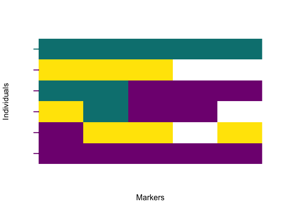

```r
# Select 40% of markers with the highest diagnostic index
threshold <- quantile(res2$DI$DI, prob = 0.6)
genotypes3 <- genotypes2[, res2$DI$DI > threshold]
# Recalculate I4 and hybrid indices
h3 <- apply(genotypes3,
            MARGIN = 1,
            FUN = \(x) pHetErrOnStateCount(sStateCount(x)))[1, ]
# Plot the polarised markers
plotPolarized(genotypes3, h3)
```

5. **How to cite `diemr`?**

To use `diemr` in a publication, please cite (Baird et al. 2023).

Baird, Stuart J. E., Jan Petružela, Izar Jaroň, Pavel Škrabánek, and Natália Martínková. 2023. “Genome Polarisation for Detecting Barriers to Geneflow.” *Methods in Ecology and Evolution* 14: 512–28. https://doi.org/10.1111/2041-210X.14010.